# 218X_R6

Jordan Brinn

12/3/2020

#Part 1 - Burden Analysis

```r
#set up
bay_county_names <-
  c(
    "Alameda",
    "Contra Costa",
    "Marin",
    "Napa",
    "San Francisco",
    "San Mateo",
    "Santa Clara",
    "Solano",
    "Sonoma"
  )

bay_counties <-
  counties("CA", cb = T, progress_bar = F) %>%
  filter(NAME %in% bay_county_names)

ca_pumasR6 <-
  pumas("CA", cb = T, progress_bar = F)

bay_pumasR6 <-
  ca_pumasR6 %>%
  st_centroid() %>%
  .[bay_counties, ] %>%
  st_set_geometry(NULL) %>%
  left_join(ca_pumasR6 %>% select(GEOID10)) %>%
  st_as_sf()

pums_vars_2019 <- #changed to 2019
  pums_variables %>%
  filter(year == 2019, survey == "acs1")
```

```r
#preaggregated housing cost variables - had to change to 2019 because 2014-2018 was too big
ca_pumsR6 <- get_pums(
  variables = c(
    "PUMA",
    "GRNTP", #renter montly costs
    "SMOCP", #owner monthly costs
    "ADJHSG",
    "HINCP",
    "ADJINC"
  ),
  state = "CA",
  year = 2019,
  survey = "acs1"
)
saveRDS(ca_pumsR6,"ca_pumsR6.rds")
```

```r
#filter pums data for bay area only
bay_pumsR6 <-
  ca_pumsR6 %>%
  filter(PUMA %in% bay_pumasR6$PUMACE10)
```

```r
#filtering pums and pumas data for SF county only
sf_county <-
  bay_counties %>%
  filter(NAME == "San Francisco")

sf_pumas <-
  bay_pumasR6 %>%
  st_centroid() %>%
  .[sf_county, ] %>%
  st_set_geometry(NULL) %>%
  left_join(bay_pumasR6 %>% select(GEOID10)) %>%
  st_as_sf()

sf_pums <-
  bay_pumsR6 %>%
  filter(PUMA %in% sf_pumas$PUMACE10)
```

```r
#SF housing burden (30%) as a percentage and absolute dollar amount
burden_threshold <- 0.3

sf_burden <-
  sf_pums %>%
  filter(HINCP > 0) %>%
  filter(SPORDER == 1) %>%
  transmute(
    PUMA = PUMA,
    weight = WGTP,
    housingcost = ifelse(
      SMOCP > 0,
      SMOCP*12*as.numeric(ADJHSG),
      GRNTP*12*as.numeric(ADJHSG)
    ),
    income = HINCP*as.numeric(ADJINC),
    burden_perc = housingcost/income,
    burden_30 = housingcost - burden_threshold*income,
    incomegap_30 = housingcost/burden_threshold - income,
    status = ifelse(
      SMOCP > 0,
      "Owner",
      "Renter"
    )
  )
```

```r
#housing burden summary for Bay Area PUMAs
sf_burden_groups <-
  sf_burden %>%
  group_by(status) %>%
  mutate(
    burdened_30 = ifelse(
      (burden_perc >= burden_threshold) ,
        weight,
        0
    ),
    excess_30 = ifelse(
      (burden_30 < 0) ,
      burden_30,
      0
    ),
    burden_30 = ifelse(
      (burden_30 > 0) ,
      burden_30,
      0
    ),
    incomegap_30 = ifelse(
      (incomegap_30 > 0),
      incomegap_30,
      0
    )
  )

sf_burden_summary <-
  sf_burden_groups %>%
    summarize(
    burdened_30 = sum(burdened_30), #number of burdened households (spend 30%+ income on housing)
    households = sum(weight), #number of households
    burden_30 = sum(burden_30*weight), #total funding that would be required to eliminate this housing burden
    incomegap_30 = sum(incomegap_30*weight), #total increase in income necessary to unburde households that are currently burdened assuming same rent/mortgage payment
    excess_30 = sum(excess_30*weight) #total amount of money that households would have pay for rent/mortage in order to become burdened (negative amount indicates higher total burden than excess)
  ) %>%
  mutate(
    burdened_30_perc = burdened_30/households #percent of households burdened in San Francisco County
  )

sf_burden_summary
```

```
## # A tibble: 2 x 7
##   status burdened_30 households burden_30 incomegap_30 excess_30
##   <chr>        <dbl>      <dbl>     <dbl>        <dbl>     <dbl>
## 1 Owner        38572     133838    7.41e8  2470497641.   -4.47e9
## 2 Renter       67449     227649    5.93e8  1978009569.   -5.48e9
## # ... with 1 more variable: burdened_30_perc <dbl>
```

```r
#joining pumas to burdened pums data, grouped by puma and renter/owner status
sf_burden_pumas <-
  sf_burden_groups %>%
  group_by(PUMA, status) %>%
  summarize(
    burdened_30 = sum(burdened_30),
    households = sum(weight),
    burden_30 = sum(burden_30*weight),
    incomegap_30 = sum(incomegap_30*weight),
    excess_30 = sum(excess_30*weight)
  ) %>%
  mutate(
    burdened_30_perc = burdened_30/households
  ) %>%
  left_join(bay_pumasR6 %>% select(PUMA = PUMACE10)) %>%
  st_as_sf()
```

```r
#Map of Owner households paying 30%+ of their income
burden_pal1 <- colorNumeric(
  palette = "Purples",
  domain = sf_burden_pumas %>%
    filter(
      status == "Owner"
    ) %>%
    pull(burdened_30_perc)
)

sf_burden_pumas %>%
  filter(
    status =="Owner"
  ) %>%
  leaflet() %>%
  addMapboxTiles(
    style_id = "streets-v11",
    username = "mapbox"
  ) %>%
  addPolygons(
    fillColor = ~burden_pal1(burdened_30_perc),
    fillOpacity = 0.5,
    color = "white",
    weight = 0.5,
    label = ~paste0(round(burdened_30_perc*100), "% of households paying 30%+ of income on housing"),
    highlightOptions = highlightOptions(
      weight = 2
    )
  ) %>%
  addLegend(
    pal = burden_pal1,
    values = ~burdened_30_perc,
    title = "% Cost-burdened<br>households"
  )
```

[interactive chart not shown]

Map of % of home owner population in each SF PUMA that spends 30%+ of their income on their annual payments

```r
#Map of % of Renter households paying 30%+ of income
burden_pal1 <- colorNumeric(
  palette = "Blues",
  domain = sf_burden_pumas %>%
    filter(
      status == "Renter"
    ) %>%
    pull(burdened_30_perc)
)

sf_burden_pumas %>%
  filter(
    status =="Renter"
  ) %>%
  leaflet() %>%
  addMapboxTiles(
    style_id = "streets-v11",
    username = "mapbox"
  ) %>%
  addPolygons(
    fillColor = ~burden_pal1(burdened_30_perc),
    fillOpacity = 0.5,
    color = "white",
    weight = 0.5,
    label = ~paste0(round(burdened_30_perc*100), "% of households paying 30%+ of income on housing"),
    highlightOptions = highlightOptions(
      weight = 2
    )
  ) %>%
  addLegend(
    pal = burden_pal1,
    values = ~burdened_30_perc,
    title = "% Cost-burdened<br>households"
  )
```

[interactive chart not shown]

Map of % of home renter population in each SF PUMA that spends 30%+ of their income on their annual payments

#Part 2 - Property Uses and Zoning

```r
#shapes of SF parcels from Open Data Portal
sf_parcels_shape <-
  st_read("https://data.sfgov.org/api/geospatial/acdm-wktn?method=export&format=GeoJSON") %>%
  filter(active == "true") %>%
  select(
    apn = blklot,
    zoning = zoning_code,
    zoning_desc = zoning_district
  )
#SF assessor-recorder propert tax roll data
temp <- tempfile()
download.file("https://sfassessor.org/sites/default/files/uploaded/2020.7.10_SF_ASR_Secured_Roll_Data_2019-2020.xlsx",destfile = temp, mode = "wb")

sf_secured <- read_excel(temp, sheet = "Roll Data 2019-2020")
datakey <- read_excel(temp, sheet = "Data Key")
usecode <- read_excel(temp, sheet = "Class Code Only")

unlink(temp)

datakey %>% select(`DATA NAME`, `FIELD NAME`) %>% as.data.frame()
```

```
##     DATA NAME                               FIELD NAME
## 1     PROPLOC                        Property Location
## 2   RP1NBRCDE                        Neighborhood Code
## 3   RP1PRCLID                     Block and Lot Number
## 4   RP1VOLUME                            Volume Number
## 5   RP1CLACDE                      Property Class Code
## 6       YRBLT                      Year Property Built
## 7       BATHS                      Number of Bathrooms
## 8        BEDS                       Number of Bedrooms
## 9       ROOMS                          Number of Rooms
## 10   STOREYNO                        Number of Stories
## 11      UNITS                          Number of Units
## 12       ZONE                              Zoning Code
## 13  CONSTTYPE                        Construction Type
## 14      DEPTH                                Lot Depth
```

[output cut: 18 more lines]

Table of data fields in the SF Assessor-Recorder data

```r
#joining property tax data to parcel shape df - will be errors
sf_parcels <-
  sf_parcels_shape %>%
  left_join(
    sf_secured %>%
      mutate(
        apn = RP1PRCLID %>%
          str_replace(" ","")
      )
  )

sum(!is.na(sf_parcels$apn)) #how many APNs sf_parcel starts with
```

```
## [1] 225086
```

```r
sum(!is.na(sf_parcels$RP1PRCLID)) #how many APNs are successfully matched with sf_secured
```

```
## [1] 213114
```

```r
sum(!is.na(sf_parcels$zoning)) #how many records in sf_parcels have zoning codes
```

```
## [1] 224330
```

```r
sum(!is.na(sf_parcels$ZONE)) #how many of the matched records from sf_secrued have zoning codes
```

```
## [1] 174558
```

```r
#Parcel data for my census tract (Asbury Heights/Haight/Cole Valley)
my_sample <-
  tracts("CA", "San Francisco", cb = T, progress_bar = F) %>%
  filter(
    TRACTCE %in% c(
      "017101"
    )
  ) %>%
  st_transform(4326)

my_parcel <-
  sf_parcels %>%
  st_centroid() %>%
  .[my_sample, ] %>%
  st_set_geometry(NULL) %>%
  left_join(sf_parcels %>% select(apn)) %>%
  st_as_sf() %>%
  filter(!is.na(RP1PRCLID))

my_parcel %>%
  leaflet() %>%
  addMapboxTiles(
    style_id = "streets-v11",
    username = "mapbox"
  ) %>%
  addPolygons(
    fillColor = "blue",
    color = "black",
    weight = 0.5,
    label = ~zoning
  )
```

[interactive chart not shown]

```r
#which parcel records are conodminiumized
duplicate_shapes <-
  my_parcel %>%
  as.data.frame() %>%
  filter(duplicated(geometry))

condo_parcels <-
  my_parcel %>%
  filter(geometry %in% duplicate_shapes$geometry)
```

```r
#what zones are included in my tract
my_parcel %>%
  st_set_geometry(NULL) %>%
  group_by(zoning, zoning_desc) %>%
  summarize(Freq = n())
```

```
## # A tibble: 7 x 3
## # Groups:   zoning [7]
##   zoning      zoning_desc                                                   Freq
##   <chr>       <chr>                                                        <int>
## 1 P           PUBLIC                                                           1
## 2 RH-1(D)     RESIDENTIAL- HOUSE, ONE FAMILY- DETACHED                        39
## 3 RH-2        RESIDENTIAL- HOUSE, TWO FAMILY                                 578
## 4 RH-2|RH-1(~ RESIDENTIAL- HOUSE, TWO FAMILY|RESIDENTIAL- HOUSE, ONE FAMI~     1
## 5 RH-3        RESIDENTIAL- HOUSE, THREE FAMILY                               344
## 6 RH-3|RH-2   RESIDENTIAL- HOUSE, THREE FAMILY|RESIDENTIAL- HOUSE, TWO FA~     5
## 7 RM-1        RESIDENTIAL- MIXED, LOW DENSITY                                  9
```

```r
#RH = Residential House Districts, RM = Residential Mixed Use Districts, P = Public Use
#RH-1(D) - One Family (attached dwelling) - single family houses with side yards (wider lots, less than 35ft)
#RH-2 - Two Family - less than 25ft wide by 40ft tall, one and two family houses, owner usually occupies one of the two family units
#RH-2|RH-1(D) --> covert to RH-2
#RH-3 - Three Family - 3 units common in addition to one and two, usually flats not apartments, nonresidential uses more common than in RH-2, ground floor outdoor spaces and decks
#RH-2|RH-2 --> convert to RH-3
#RM-1 - Low Density - mixture of dwelling types, lots of apartment buildings, generally 25-35 ft wide and 40 ft high. Separate entrances for groups of units, ground floor and top floor outdoor spaces, nonresidential uses
```

Table of zoning codes included in the parcel. Mostly Residential Housing category.

```r
#summary of stats
table(my_parcel$RP1CLACDE) %>%
  as.data.frame() %>%
  left_join(usecode, by = c("Var1"= "CODE")) %>%
  select(Freq, DESCRIPTION)
```

```
##    Freq                     DESCRIPTION
## 1    45       Apartment 4 units or less
## 2     6      Apartment 15 Units or more
## 3    57         Apartment 5 to 14 Units
## 4     2               Commercial Stores
## 5   363                        Dwelling
## 6     6 Dwellings - Apt 4 units or less
## 7     1                         Schools
## 8   172                  Flats & Duplex
## 9     1             Flats 5 to 14 units
## 10    1    Flat & Store 4 units or less
## 11    1      Flat & Store 5 to 14 units
## 12    2                  Hotels - Other
## 13    2      Convalescent/Nursing Homes
## 14    3        TIC Bldg 4 units or less
## 15    1                      Vacant Lot
## 16    1                            <NA>
## 17    3          Vacant Lot Residential
## 18    2     Churches,Convents,Rectories
## 19  308                     Condominium
```

Summary of specific building uses in the parcel

```r
#cleaning data of parcel to filter out public property, convert zones listed under two codes to one code, and add a column with potential building height based on zoning
my_parcel_clean <-
  my_parcel %>%
  mutate(
    zoning = case_when(
      zoning == "RH-2|RH-1(D)" ~ "RH-2",
      zoning == "RH-3|RH-2" ~ "RH-3",
      TRUE ~ zoning
    )
  ) %>%
  filter(zoning != "P") %>%
  as.data.frame() %>%
  mutate(geometry = geometry %>% st_as_text()) %>%
  group_by(geometry) %>%
  summarize(
    apn = first(apn),
    zoning = first(zoning),
    units = sum(UNITS, na.rm = T),
    stories = max(STOREYNO, na.rm = T),
    floorarea = sum(SQFT, na.rm = T)
  ) %>%
  ungroup() %>%
  select(-geometry) %>%
  left_join(my_parcel %>% select(apn)) %>%
  st_as_sf() %>%
  mutate(
    gen_hght = ifelse(
      zoning == "RM-1",
      40,
      35
    )
  )
```

```r
#create and append max_floorarea, max_units, and max_stories to existing dataframe. create unused_floorarea, unused_units, and unused_stories (max - current)

projection <- "+proj=utm +zone=10 +ellps=GRS80 +datum=NAD83 +units=ft +no_defs" #want in sqft

my_parcel_zoning <-
  my_parcel_clean %>%
  st_centroid() %>%
  st_set_geometry(NULL) %>%
  left_join(my_parcel_clean %>% select(apn)) %>%
  st_as_sf() %>%
  st_transform(projection) %>%
  mutate(
    lotarea = st_area(.) %>% as.numeric(), #need numeric because in units format
    max_floorarea =  lotarea*1.8,
    unused_floorarea = ifelse(
      (max_floorarea - floorarea) > 0,
      (max_floorarea - floorarea),
      0
    ),
    max_units = case_when(
      zoning == "RH-1(D)" ~ 1,
      zoning == "RH-2" ~ 2,
      zoning == "RH-3" ~ 3,
      zoning == "RM-1" ~ pmax(3, floor(lotarea/800)), #pmax finds highest of value set
    ),
    unused_units = ifelse(
      (max_units - units) > 0,
      (max_units - units),
      0
    ),
    max_height = gen_hght ,
    max_stories = floor(max_height/11),
    unused_stories = ifelse(
      (max_stories - stories) > 0,
      (max_stories - stories),
      0
    )
  ) %>%
  st_transform(4326)
```

Unused floor area and unused units indicate underutilization based on current zoning. This parcel could be more densely populated without any rezoning efforts

```r
sum(my_parcel_zoning$unused_floorarea, na.rm = T) #total unused floor area in parcel
```

```
## [1] 1690192
```

```r
sum(my_parcel_zoning$unused_units, na.rm = T) #total unused units in parcel
```

```
## [1] 649
```

```r
#plot of unused floor area
floorarea_pal <- colorBin(
  palette = "Greens",
  bins = c(0,1000,5000,10000,max(my_parcel_zoning$unused_floorarea, na.rm = T))
) #manually set bins because of high outliers (5 in 10,000-20,000 range) --> the plots along buena vista have been under construction for 6 months now, so maybe this will improve

leaflet() %>%
  addMapboxTiles(
    style_id = "light-v9",
    username = "mapbox"
  ) %>%
  addPolygons(
    data = my_parcel_zoning,
    fillColor = ~floorarea_pal(unused_floorarea),
    fillOpacity = 0.75,
    color = "white",
    weight = 0.5,
    label = ~round(unused_floorarea)
  ) %>%
  addLegend(
    data = my_parcel_zoning,
    pal = floorarea_pal,
    values = ~unused_floorarea,
    title = "Unused Floor Area"
  )
```

[interactive chart not shown]

Map of unused floor area by parcel. Two of the highest underutilized parcels are currently undergoing major renovations, so they will potentially be less underutilized in the future.

```r
#plot of additional allowed units (#unused units)
units_pal <- colorBin(
  palette = "Purples",
  bins = c(0,1,2,3) #no unused > 3
)

leaflet() %>%
  addMapboxTiles(
    style_id = "light-v9",
    username = "mapbox"
  ) %>%
  addPolygons(
    data = my_parcel_zoning,
    fillColor = ~units_pal(unused_units),
    fillOpacity = 0.75,
    color = "white",
    weight = 0.5,
    label = ~round(unused_units)
  ) %>%
  addLegend(
    data = my_parcel_zoning,
    pal = units_pal,
    values = ~unused_units,
    title = "Additional Units<br>Allowed"
  )
```

[interactive chart not shown]

Map of additional units allowed on each parcel. No parcel has potential for more than 3 units, but these numbers are still quite high considering most of these buildings are not allowed to have more than 3 units based on zoning. The area consists of mostly of large homes, many of which have been subdivided into multiple units. This often results in units being larger than necessary since it is often easiest to make one entire floor into it’s own unit. The southern section of this parcel contains many homes which have not been subdivided.

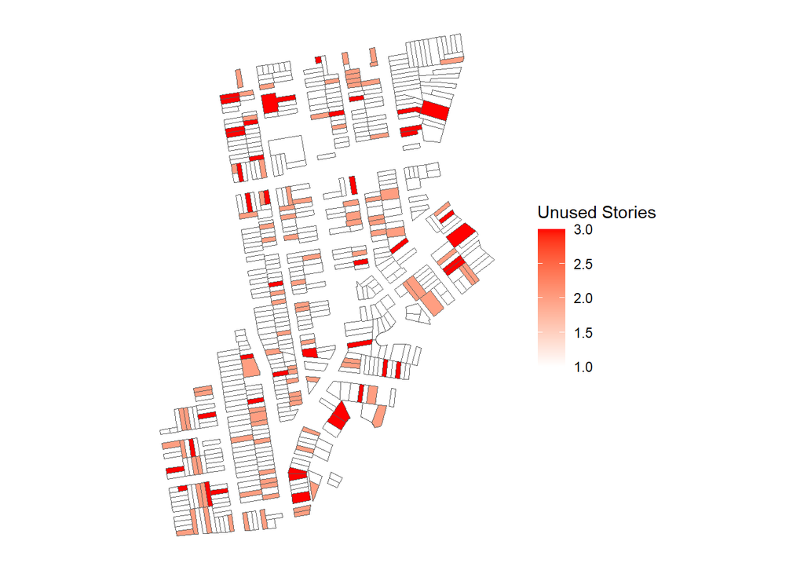

```r
#ggplot of unused stories instead of leaflet
my_stories_plot <-
  my_parcel_zoning %>%
  filter(unused_stories > 0) %>%
  ggplot() +
  geom_sf(
    aes(
      fill = unused_stories
    ),
    lwd = 0
  ) +
  theme(
    axis.text.x = element_blank(),
    axis.text.y = element_blank(),
    axis.ticks = element_blank(),
    rect = element_blank()
  ) +
  labs(
    fill = "Unused Stories"
  ) +
  scale_fill_gradient(
    low = "white",
    high = "red"
  )

my_stories_plot
```

Map of unused stories by parcel. This assumes each floor would be 11 ft high, which, given that much of the parcels are in the Residential Housing zoning category, would mean that many buildings could have a maximum of three stories since the maximum height is restricted to 35 feet. With other buildings such as those in Residential Mixed zoning, the maximum height is 40ft which would also only allow for 3 stories based on the 11 ft per story assumption, but in reality, they may be able to include another floor.